# Introduction to Mixed Models using R

Dominique Makowski

May 2021

# What are Mixed Models

## All statistical tests are linear models

[figure not shown]

https://lindeloev.github.io/tests-as-linear *(Google “tests linear models”)*

## Whole World of Models

- LM: Linear Model
- GLM: General Linear Model (logistic, count, zero-inflated, …)
- GAM: General Additive Model
- GLMM / GAMM: **Mixed** GLM / GAM
- Bayesian Models
- e.g. *Bayesian Scale-Location Mixed Shifted Log-normal General Additive Model*

## What does “Mixed” Mean

- Full name actually “Mixed **Effects**” Model
- Includes **random effects** on top of the **fixed effects** (the model’s main predictors)
- Confusing names
- Better term is “Hierarchical” Model
- Hierarchical data is organized in *groups* which by themselves explain some variance
- Groups can be any structure in the data, e.g., participants, items, datasets, …

## Why use Mixed Models

- Powerful (allows the quantification of a lot of interesting parameters)
- Appropriate for the data we have in psychology / neuroscience
- In 99% of cases, there is no reason to use anything else than mixed models
- Should be the default of stats in psychology

# Preparation

## Packages

```r
install.packages(c("dplyr", "ggplot2", "lme4", "parameters", "modelbased", "report"))
```

```r
# Data Wrangling and plotting
library(dplyr)
library(ggplot2)

# Model fitting
library(lme4)

# Model analysis
library(report)
library(parameters)
library(modelbased)
```

## Data

```r
# Load data from URL (must be on one line)
df <- read.csv("https://raw.githubusercontent.com/
                DominiqueMakowski/teaching/master/
                R/2021_05_CBL_MixedModels/data.csv")
```

```r
report(df)
```

```
## The data contains 800 observations of the following 3 variables:
##   - RT: n = 800, Mean = 3.36, SD = 3.90, Median = 3.29, MAD = 3.93, range: [-8.40, 14.30], Skewness = 0.04, Kurtosis = 8.34e-03, 0% missing
##   - Difficulty: n = 800, Mean = -3.15, SD = 1.99, Median = -3.13, MAD = 2.33, range: [-8.32, 1.59], Skewness = 1.88e-03, Kurtosis = -0.71, 0% missing
##   - Participant: 20 entries, such as S01 (5.00%); S02 (5.00%); S03 (5.00%) and 17 others (0 missing)
```

```r
head(df)
```

```
##            RT Difficulty Participant
## 1 -0.12750793 -0.2648646         S01
## 2  0.09820696 -2.1964455         S01
## 3  0.63309481  1.5942382         S01
## 4 -1.65751359 -1.3198649         S01
## 5  2.56891237  0.9067950         S01
## 6  0.19993762  0.6397441         S01
```

## Data and Goals

- 20 participants did a task with 40 trials (= 800 observations)
- For each trial, their RT was recorded and they reported the “subjective” difficulty
- **What’s the relationship between RT and Subjective Difficulty?**
- **Hypothesis**: Higher subjective difficulty = Higher RT (slower reaction)

# ANOVA

- repeated-measures ANOVAs are a statistical abominations
- We need to group participants based on their average RT and reported difficulty

## Summarize the data by participant

- Get **individual difficulty scores** and **average RT**

```r
dfsub <- df %>%
  group_by(Participant) %>%
  summarise_all(mean)

dfsub
```

```
## # A tibble: 20 x 3
##    Participant      RT Difficulty
##    <chr>         <dbl>      <dbl>
##  1 S01          0.987        -0.3
##  2 S02         -0.0485       -0.6
##  3 S03          0.193        -0.9
##  4 S04          1.04         -1.2
##  5 S05          1.79         -1.5
##  6 S06          2.69         -1.8
##  7 S07          3.10         -2.1
##  8 S08          2.00         -2.4
##  9 S09          2.90         -2.7
## 10 S10          2.65         -3
## 11 S11          3.91         -3.3
## 12 S12          4.29         -3.6
## 13 S13          4.09         -3.9
## 14 S14          4.10         -4.2
## 15 S15          4.83         -4.5
## 16 S16          5.18         -4.8
## 17 S17          5.49         -5.1
## 18 S18          6.02         -5.4
## 19 S19          5.73         -5.7
## 20 S20          6.25         -6
```

## Dichotomize the participants

- We split the participants into 2 groups based on their average difficulty

```r
dfsub$Difficulty_Group <- ifelse(dfsub$Difficulty < mean(dfsub$Difficulty),
                                 "Reported_Easy", "Reported_Hard")
```

## Run an ANOVA

```r
model <- aov(RT ~ Difficulty_Group, data = dfsub)

report(model)
```

```
## The ANOVA (formula: RT ~ Difficulty_Group) suggests that:
##
##   - The main effect of Difficulty_Group is statistically significant and large (F(1, 18) = 51.92, p < .001; Eta2 = 0.74, 90% CI [0.54, 0.84])
##
## Effect sizes were labelled following Field's (2013) recommendations.
```

## Conclusion

- We can conclude that 🤷

## Conclusion (2)

- ANOVAs are just uninformative summaries of linear models

```r
model <- anova(lm(RT ~ 1 + Difficulty_Group, data = dfsub))

report(model)
```

```
## The ANOVA suggests that:
##
##   - The main effect of Difficulty_Group is statistically significant and large (F(1, 18) = 51.92, p < .001; Eta2 = 0.74, 90% CI [0.54, 0.84])
##
## Effect sizes were labelled following Field's (2013) recommendations.
```

# Linear Model

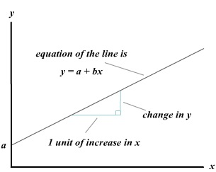

- $y = a + bx$ equivalent to $y \thicksim a(1) + b(x)$
- becomes in R: $response \thicksim Intercept(1) + \beta(Var1)$

## In R

- No need to explicitly specify the intercept (`~ 1 + ...`), it’s added by default

```r
model <- lm(RT ~ Difficulty_Group, data = dfsub)

report(model)
```

```
## We fitted a linear model (estimated using OLS) to predict RT with Difficulty_Group (formula: RT ~ Difficulty_Group). The model explains a statistically significant and substantial proportion of variance (R2 = 0.74, F(1, 18) = 51.92, p < .001, adj. R2 = 0.73). The model's intercept, corresponding …
##
##   - The effect of Difficulty_Group [Reported_Hard] is statistically significant and negative (beta = -3.26, 95% CI [-4.21, -2.31], t(18) = -7.21, p < .001; Std. beta = -1.68, 95% CI [-2.17, -1.19])
##
## Standardized parameters were obtained by fitting the model on a standardized version of the dataset.
```

## Continuous Predictor

```r
model <- lm(RT ~ Difficulty, data = dfsub)

report(model)
```

```
## We fitted a linear model (estimated using OLS) to predict RT with Difficulty (formula: RT ~ Difficulty). The model explains a statistically significant and substantial proportion of variance (R2 = 0.94, F(1, 18) = 284.12, p < .001, adj. R2 = 0.94). The model's intercept, corresponding to Difficul…
##
##   - The effect of Difficulty is statistically significant and negative (beta = -1.06, 95% CI [-1.19, -0.93], t(18) = -16.86, p < .001; Std. beta = -0.97, 95% CI [-1.09, -0.85])
##
## Standardized parameters were obtained by fitting the model on a standardized version of the dataset.
```

```r
parameters(model)
```

```
## Parameter   | Coefficient |   SE |         95% CI |  t(18) |      p
## -------------------------------------------------------------------
## (Intercept) |        0.02 | 0.23 | [-0.45,  0.50] |   0.10 | 0.923
## Difficulty  |       -1.06 | 0.06 | [-1.19, -0.93] | -16.86 | < .001
```

The two parameters are the **intercept** and the **slope**.

## Visualization (1) relation estimation

```r
viz_data <- estimate_relation(model)
viz_data
```

```
##    Difficulty Predicted        SE     CI_low   CI_high
## 1  -6.0000000 6.3830054 0.2096881  5.9424671 6.8235437
## 2  -5.3666667 5.7115785 0.1768481  5.3400344 6.0831226
## 3  -4.7333333 5.0401516 0.1474954  4.7302754 5.3500279
## 4  -4.1000000 4.3687247 0.1241288  4.1079397 4.6295097
## 5  -3.4666667 3.6972978 0.1106097  3.4649154 3.9296803
## 6  -2.8333333 3.0258710 0.1106097  2.7934885 3.2582534
## 7  -2.2000000 2.3544441 0.1241288  2.0936590 2.6152291
## 8  -1.5666667 1.6830172 0.1474954  1.3731409 1.9928934
## 9  -0.9333333 1.0115903 0.1768481  0.6400462 1.3831344
## 10 -0.3000000 0.3401634 0.2096881 -0.1003749 0.7807017
```

## Visualization (2) relation plotting

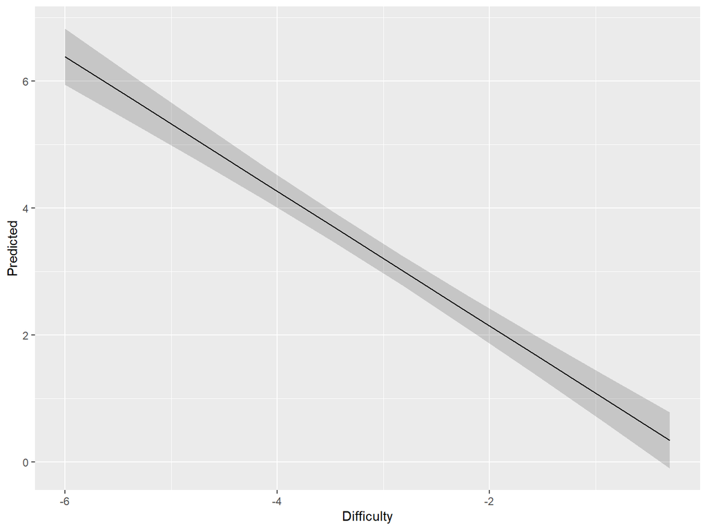

```r
p <- ggplot(data = viz_data, aes(x = Difficulty, y = Predicted)) +
  geom_line() +
  geom_ribbon(aes(ymin = CI_low, ymax = CI_high), alpha = 0.2)
p
```

## Visualization (3) add original data

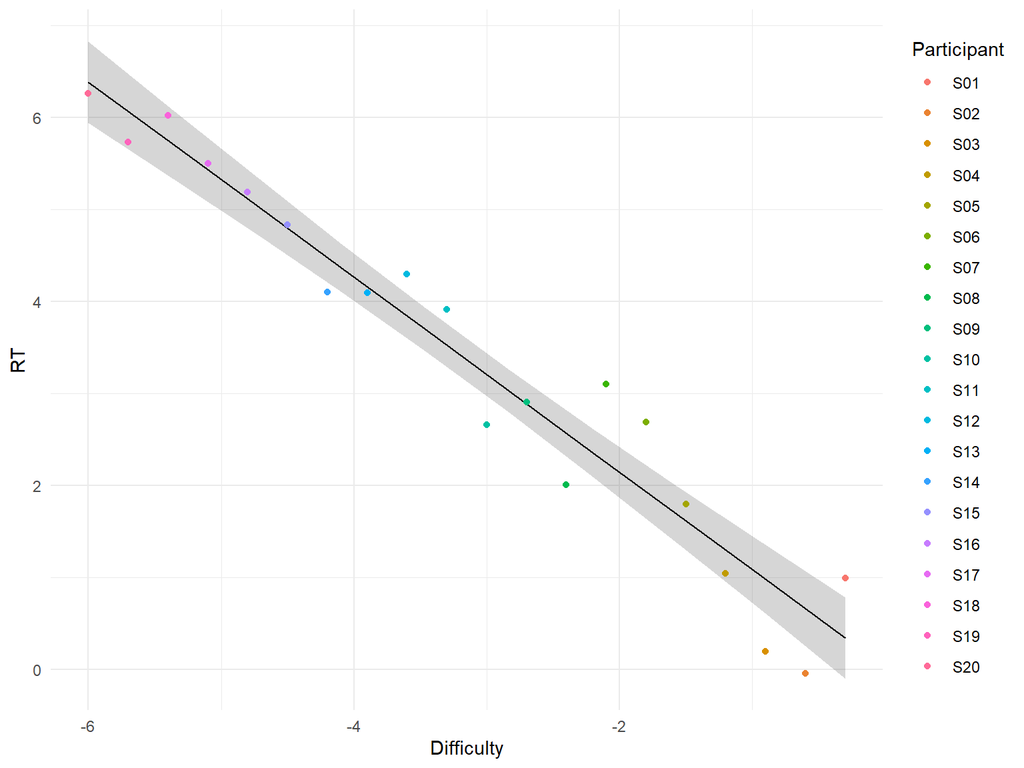

```r
p <- p +
  geom_point(data = dfsub, aes(x = Difficulty, y = RT, color = Participant)) +
  ylab("RT") +
  theme_minimal()
p
```

## Conclusion

- Subjective difficulty is negatively associated with RT
- The harder the task is, the faster they are
- Mmmh 🤔

# Linear Mixed Model

## Using all data

```r
model <- lm(RT ~ Difficulty, data = df)

summary(report(model))
```

```
## We fitted a linear model to predict RT with Difficulty. The model's explanatory power is weak (R2 = 0.11, adj. R2 = 0.11). The model's intercept is at 1.34 (95% CI [0.86, 1.82]). Within this model:
##
##   - The effect of Difficulty is statistically significant and negative (beta = -0.64, 95% CI [-0.77, -0.51], t(798) = -9.81, p < .001, Std. beta = -0.33)
```

Problems:

- Assumed independence of observations
- Inflated statistical power
- Information about group lost

Solutions:

- Mixed model

## Mixed model (random intercept)

```r
model <- lmer(RT ~ Difficulty + (1|Participant), data = df)

report(model)
```

```
## We fitted a linear mixed model (estimated using REML and nloptwrap optimizer) to predict RT with Difficulty (formula: RT ~ Difficulty). The model included Participant as random effect (formula: ~1 | Participant). The model's total explanatory power is substantial (conditional R2 = 0.41) and the p…
##
##   - The effect of Difficulty is statistically significant and positive (beta = 0.46, 95% CI [0.23, 0.68], t(796) = 3.98, p < .001; Std. beta = 0.23, 95% CI [0.12, 0.35])
##
## Standardized parameters were obtained by fitting the model on a standardized version of the dataset. 95% Confidence Intervals (CIs) and p-values were computed using the Wald approximation.
```

## Get parameters

```r
parameters(model, effects = "fixed")
```

```
## # Fixed Effects
##
## Parameter   | Coefficient |   SE |       95% CI | t(796) |      p
## -----------------------------------------------------------------
## (Intercept) |        4.81 | 0.71 | [3.41, 6.21] |   6.74 | < .001
## Difficulty  |        0.46 | 0.12 | [0.23, 0.68] |   3.98 | < .001
```

## Visualizing

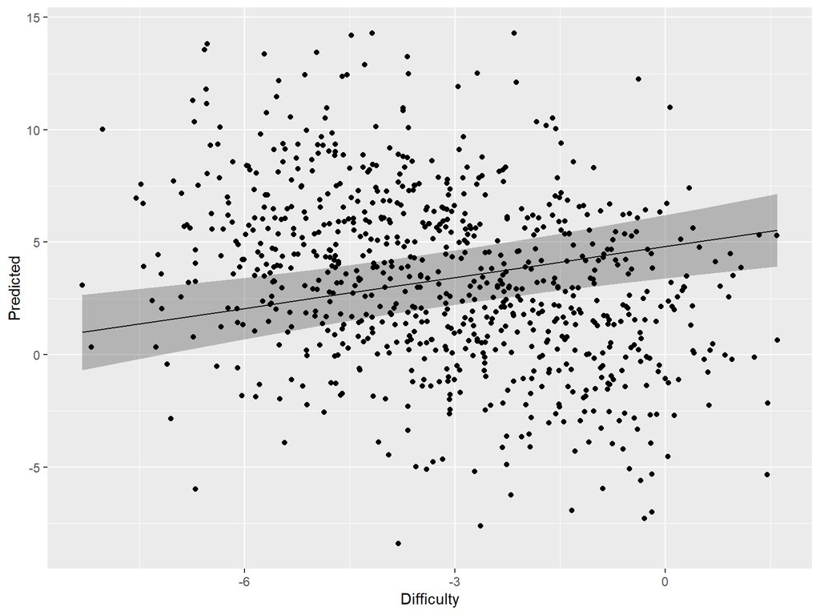

```r
viz_data <- estimate_relation(model)

p <- ggplot(data = viz_data, aes(x = Difficulty, y = Predicted)) +
  geom_line() +
  geom_ribbon(aes(ymin = CI_low, ymax = CI_high), alpha = 0.3) +
  geom_point(data = df, aes(x = Difficulty, y = RT))
p
```

## Visualizing - color

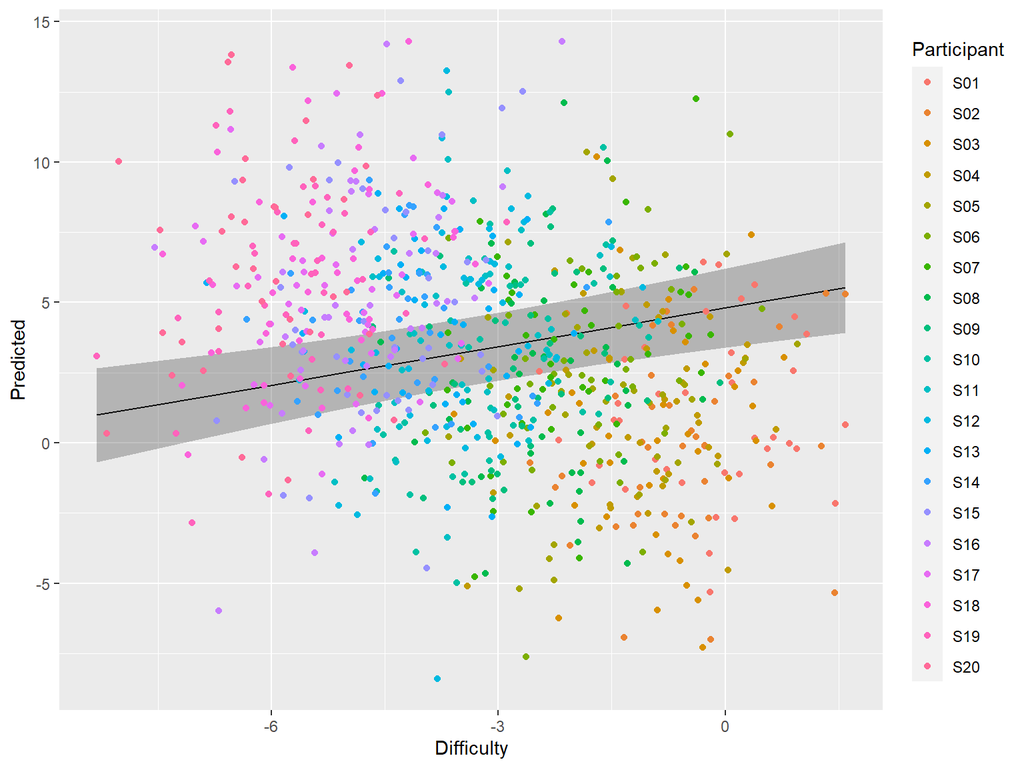

```r
p <- ggplot(data = viz_data, aes(x = Difficulty, y = Predicted)) +
  geom_line() +
  geom_ribbon(aes(ymin = CI_low, ymax = CI_high), alpha = 0.3) +
  geom_point(data = df, aes(x = Difficulty, y = RT, color = Participant))
p
```

## Visualizing - random

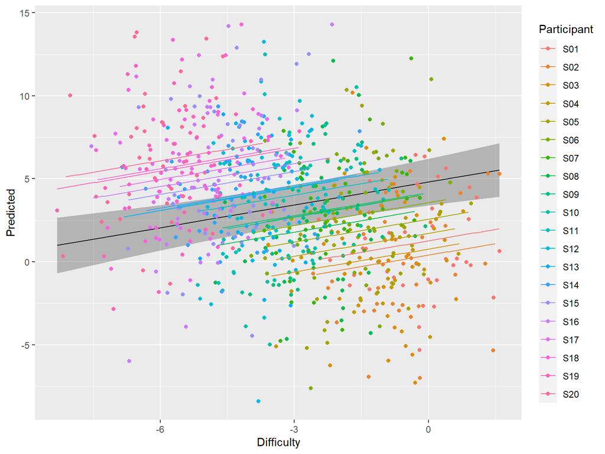

```r
viz_data_random <- estimate_relation(model,
                                     include_random = TRUE,
                                     preserve_range = TRUE,
                                     length = 100)

p <- p +
  geom_line(data = viz_data_random, aes(color = Participant))
p
```

## What happened ?

- The model estimates two “fixed” parameters (across participants) of difficulty: the **intercept** and the **slope**
- It also estimates intercepts for all groups (the “random” variable)
- The “fixed” effects are informed by random effects, and **vice versa** (shrinkage)

## Mixed model (random intercept and random slope)

```r
model <- lmer(RT ~ Difficulty + (1 + Difficulty | Participant), data = df)

parameters(model, effects = "fixed")
```

```
## # Fixed Effects
##
## Parameter   | Coefficient |   SE |       95% CI | t(794) |      p
## -----------------------------------------------------------------
## (Intercept) |        4.98 | 0.81 | [3.39, 6.57] |   6.13 | < .001
## Difficulty  |        0.46 | 0.13 | [0.19, 0.72] |   3.41 | < .001
```

- Both the intercept and the slope are estimated as fixed effects and for each level of the random variable

## Visualizing

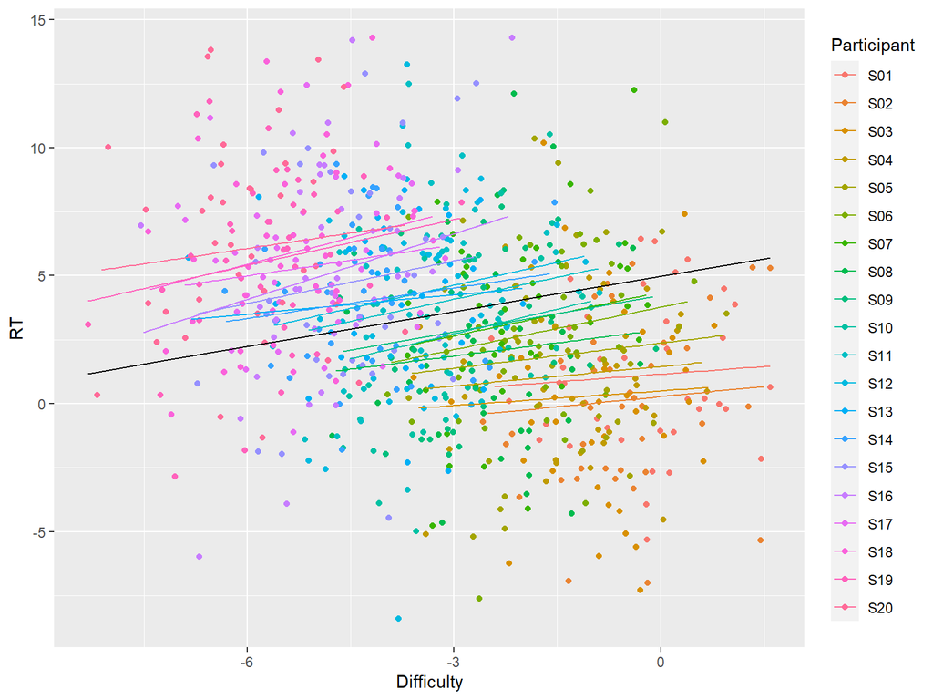

```r
viz_data_fixed <- estimate_relation(model, include_random = FALSE)
viz_data_random <- estimate_relation(model, include_random = TRUE, preserve_range = TRUE, length = 100)

ggplot() +
  geom_point(data = df, aes(x = Difficulty, y = RT, color = Participant)) +
  geom_line(data = viz_data_fixed, aes(x = Difficulty, y = Predicted)) +
  geom_line(data = viz_data_random, aes(x = Difficulty, y = Predicted, color = Participant))
```

## Extracting random parameters

```r
dfrandom <- parameters(model, effects = "random", group_level = TRUE)

as.data.frame(dfrandom)
```

```
##      Parameter Level Coefficient        SE   CI     CI_low    CI_high Effects
## 1  (Intercept)   S01 -3.82551598 0.5396578 0.95 -4.8832259 -2.7678061  random
## 2  (Intercept)   S02 -4.69945624 0.5599088 0.95 -5.7968572 -3.6020552  random
## 3  (Intercept)   S03 -4.47920880 0.5881192 0.95 -5.6319013 -3.3265163  random
## 4  (Intercept)   S04 -3.52154145 0.6238214 0.95 -4.7442088 -2.2988741  random
## 5  (Intercept)   S05 -2.61111281 0.6663726 0.95 -3.9171791 -1.3050465  random
## 6  (Intercept)   S06 -1.20469907 0.7150524 0.95 -2.6061761  0.1967780  random
## 7  (Intercept)   S07 -0.61284903 0.7691335 0.95 -2.1203230  0.8946250  random
## 8  (Intercept)   S08 -2.08462904 0.8279229 0.95 -3.7073280 -0.4619301  random
## 9  (Intercept)   S09 -0.75416543 0.8907798 0.95 -2.5000618  0.9917309  random
## 10 (Intercept)   S10 -0.31067315 0.9571187 0.95 -2.1865913  1.5652450  random
## 11 (Intercept)   S11  0.82390451 1.0264033 0.95 -1.1878091  2.8356181  random
## 12 (Intercept)   S12  1.44769158 1.0981390 0.95 -0.7046213  3.6000044  random
## 13 (Intercept)   S13  0.02635696 1.1718635 0.95 -2.2704532  2.3231671  random
## 14 (Intercept)   S14  0.73655110 1.2471398 0.95 -1.7077980  3.1809002  random
```

[output cut: 67 more lines]

## Back to the individual scores

```r
dfsub$random_coef <- dfrandom$Coefficient[1:20]  # Where Parameters == (Intercept)

report(cor.test(dfsub$Difficulty, dfsub$random_coef))
```

```
## Effect sizes were labelled following Funder's (2019) recommendations.
##
## The Pearson's product-moment correlation between dfsub$Difficulty and dfsub$random_coef is negative, statistically significant, and very large (r = -0.96, 95% CI [-0.98, -0.90], t(18) = -14.49, p < .001)
```

## Take Home Message

- Mixed models allow for the estimation (i.e., quantification) of individuals’ characteristics under the regression framework
- These individual’s characteristics in turn inform the population-level parameters
- The model-based approach allows to incorporate more sources of variance and quantify uncertainty
- Powerful and well-understood framework that is flexible and informative

## Conclusion

- Use mixed models

## Resources

- Mixed models
  - **Mixed Models with R** *(https://m-clark.github.io/mixed-models-with-R/)*
  - Singmann, H., & Kellen, D. (2019). **An Introduction to Mixed Models for Experimental Psychology**. *(preprint available online)*
- General / Other
  - **R for Psychological Science** *(https://psyr.djnavarro.net/)*
  - **YaRrr! The Pirate’s Guide to R** *(https://bookdown.org/ndphillips/YaRrr/)*
  - **GAMs in R** *(https://noamross.github.io/gams-in-r-course/)*